# Simple regressions NII on IR

# Libraries

```r
library(readr)
library(dplyr)
library(stargazer)
library(forecast)
library(lubridate)
library(stats)
```

## Reading data

```r
data <- read_csv("data/for_regressing/interbank_nii.csv")
data_clean <- na.omit(data)
```

# Modeling

## First simple model

```r
model <- lm(NII ~ IR, data = data_clean)

stargazer(model, type = "text", align = TRUE, single.row = TRUE)
```

```
##
## ===============================================
##                         Dependent variable:
##                     ---------------------------
##                                 NII
## -----------------------------------------------
## IR                      0.0002*** (0.00003)
## Constant                 0.012*** (0.0005)
## -----------------------------------------------
## Observations                    62
## R2                             0.290
## Adjusted R2                    0.278
## Residual Std. Error       0.002 (df = 60)
## F Statistic           24.537*** (df = 1; 60)
## ===============================================
## Note:               *p<0.1; **p<0.05; ***p<0.01
```

```r
cat(paste("AIC: ", AIC(model)))
```

```
## AIC:  -598.28833390611
```

## First lagged model

```r
data_clean <- data_clean %>%
  mutate(IR_lag1 = lag(IR, 1),
         IR_lag2 = lag(IR, 2),
         IR_lag3 = lag(IR, 3))

model <- lm(NII ~ IR + IR_lag1 + IR_lag2 + IR_lag3, data = data_clean)

stargazer(model, type = "text", align = TRUE, single.row = TRUE)
```

```
##
## ===============================================
##                         Dependent variable:
##                     ---------------------------
##                                 NII
## -----------------------------------------------
## IR                        0.0001 (0.0001)
## IR_lag1                  0.00005 (0.0001)
## IR_lag2                   0.0001 (0.0001)
## IR_lag3                 0.0001** (0.00004)
## Constant                 0.010*** (0.0005)
## -----------------------------------------------
## Observations                    59
## R2                             0.546
## Adjusted R2                    0.513
## Residual Std. Error       0.002 (df = 54)
## F Statistic           16.266*** (df = 4; 54)
## ===============================================
## Note:               *p<0.1; **p<0.05; ***p<0.01
```

```r
cat(paste("AIC: ", AIC(model)))
```

```
## AIC:  -587.029235492865
```

This model is actually worse than the original one indicating that I need to somehow determine which exact lags to use.

# Correlation functions

From what I know usually people use these things to determine which lags to use, but I don’t find them very useful. Still I decided to plot them anyways.

## ACF

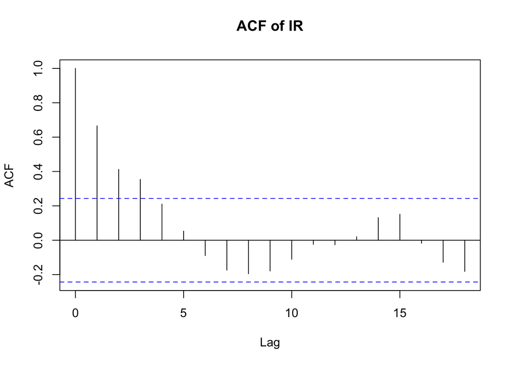

```r
acf(data$IR, main="ACF of IR")
```

## PCF

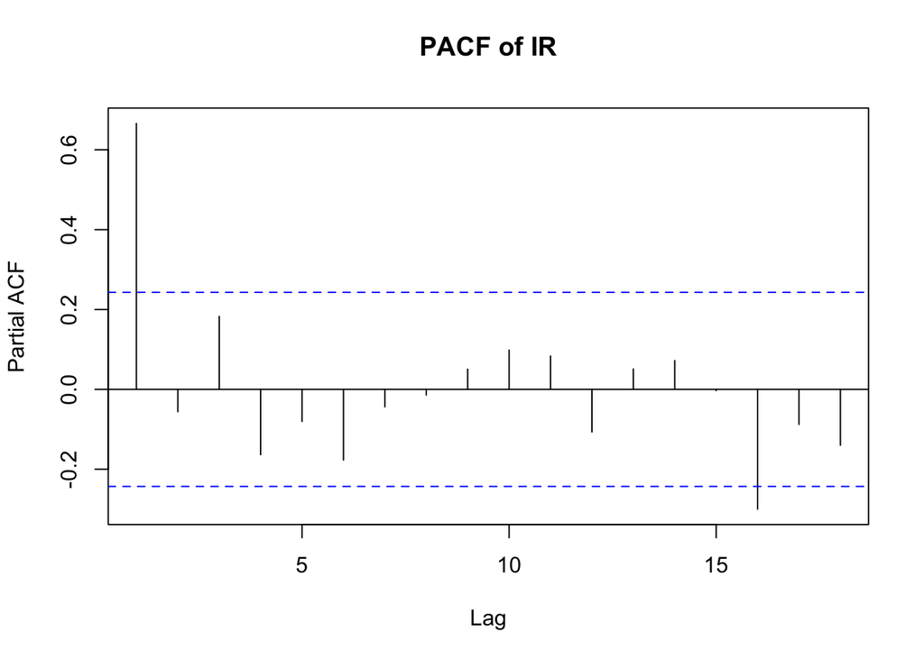

```r
pacf(data$IR, main="PACF of IR")
```

# Best possible model

## Best by AIC

```r
data$Date <- ymd(data$Date)

basic_model <- lm(NII ~ IR, data = data)

stargazer(basic_model, title = "Basic Model", type = "text", align = TRUE, single.row = TRUE)
```

```
##
## Basic Model
## ===============================================
##                         Dependent variable:
##                     ---------------------------
##                                 NII
## -----------------------------------------------
## IR                      0.0002*** (0.00003)
## Constant                 0.012*** (0.0005)
## -----------------------------------------------
## Observations                    62
## R2                             0.290
## Adjusted R2                    0.278
## Residual Std. Error       0.002 (df = 60)
## F Statistic           24.537*** (df = 1; 60)
## ===============================================
## Note:               *p<0.1; **p<0.05; ***p<0.01
```

```r
cat(paste("AIC: ", AIC(basic_model)))
```

```
## AIC:  -598.28833390611
```

```r
create_lags <- function(data, var, max_lag) {
  for (i in 1:max_lag) {
    data[paste0(var, "_lag", i)] <- lag(data[[var]], i)
  }
  return(data)
}

data_with_lags <- create_lags(data, "IR", 24)

test_lag_combinations <- function(data, max_lag) {
  best_model <- NULL
  best_aic <- Inf

  for (i in 1:max_lag) {
    for (combination in combn(1:max_lag, i, simplify = FALSE)) {
      formula <- as.formula(paste("NII ~", paste(paste0("IR_lag", combination), collapse = " + ")))
      model <- lm(formula, data = data)
      current_aic <- AIC(model)

      if (current_aic < best_aic) {
        best_model <- model
        best_aic <- current_aic
      }
    }
  }

  return(best_model)
}

best_model <- test_lag_combinations(data_with_lags, 24)

cat('\n\n')
```

```r
stargazer(best_model, title = "Best model", type = "text", align = TRUE, single.row = TRUE)
```

```
##
## Best model
## ===============================================
##                         Dependent variable:
##                     ---------------------------
##                                 NII
## -----------------------------------------------
## IR_lag1                 0.0001*** (0.00003)
## IR_lag3                 0.0001*** (0.00003)
## Constant                 0.011*** (0.0004)
## -----------------------------------------------
## Observations                    62
## R2                             0.519
## Adjusted R2                    0.503
## Residual Std. Error       0.002 (df = 59)
## F Statistic           31.879*** (df = 2; 59)
## ===============================================
## Note:               *p<0.1; **p<0.05; ***p<0.01
```

```r
cat(paste("AIC: ", AIC(best_model)))
```

```
## AIC:  -620.45791786577
```

```r
cat('\n')
```

```r
cat(paste("Best model formula:", deparse(formula(best_model))))
```

```
## Best model formula: NII ~ IR_lag1 + IR_lag3
```

So the best model is the one with lag 1 and 3. Lag 1 makes sense as it is expected to have a big effect due to the delayed effect that such policy changes can have. Why Lag 3 is so good I do not understand.

```r
model <- lm(NII ~ IR + IR_lag1 + IR_lag3, data = data_with_lags)

stargazer(model, type = "text", align = TRUE, single.row = TRUE)
```

```
##
## ===============================================
##                         Dependent variable:
##                     ---------------------------
##                                 NII
## -----------------------------------------------
## IR                       0.00004 (0.00004)
## IR_lag1                 0.0001*** (0.00004)
## IR_lag3                 0.0001*** (0.00003)
## Constant                 0.010*** (0.0005)
## -----------------------------------------------
## Observations                    62
## R2                             0.530
## Adjusted R2                    0.505
## Residual Std. Error       0.002 (df = 58)
## F Statistic           21.766*** (df = 3; 58)
## ===============================================
## Note:               *p<0.1; **p<0.05; ***p<0.01
```

```r
cat(paste("AIC: ", AIC(model)))
```

```
## AIC:  -619.789192775347
```

It’s interesting that adding a non lagged IR actually results in a worse model if we compare AIC scores. This kind of makes sense as the effect of changes to IR is always delayed. But also if we compare the $R^2$ of different models then this model is better.

## Best by $R^2$

Just for fun I also checked what is the best model according to $R^2$. I know it’s not designed for comparing models but still I thought we might see something interesting.

```r
data$Date <- ymd(data$Date)

# Basic regression
basic_model <- lm(NII ~ IR, data = data)

stargazer(basic_model, title = "Basic Model", type = "text", align = TRUE, single.row = TRUE)
```

```
##
## Basic Model
## ===============================================
##                         Dependent variable:
##                     ---------------------------
##                                 NII
## -----------------------------------------------
## IR                      0.0002*** (0.00003)
## Constant                 0.012*** (0.0005)
## -----------------------------------------------
## Observations                    62
## R2                             0.290
## Adjusted R2                    0.278
## Residual Std. Error       0.002 (df = 60)
## F Statistic           24.537*** (df = 1; 60)
## ===============================================
## Note:               *p<0.1; **p<0.05; ***p<0.01
```

```r
# Function to create lagged variables
create_lags <- function(data, var, max_lag) {
  for (i in 1:max_lag) {
    data[paste0(var, "_lag", i)] <- lag(data[[var]], i)
  }
  return(data)
}

# Create lagged variables for IR
data_with_lags <- create_lags(data, "IR", 24)

# Function to test all possible lag combinations
test_lag_combinations <- function(data, max_lag) {
  best_model <- NULL
  best_r2 <- 0

  for (i in 1:max_lag) {
    for (combination in combn(1:max_lag, i, simplify = FALSE)) {
      formula <- as.formula(paste("NII ~", paste(paste0("IR_lag", combination), collapse = " + ")))
      model <- lm(formula, data = data)
      current_r2 <- summary(model)$r.squared

      if (current_r2 > best_r2) {
        best_model <- model
        best_r2 <- current_r2
      }
    }
  }

  return(best_model)
}

# Find the best model
best_model <- test_lag_combinations(data_with_lags, 12)

cat('\n\n')
```

```r
stargazer(best_model, title = "Best model", type = "text", align = TRUE, single.row = TRUE)
```

```
##
## Best model
## ===============================================
##                         Dependent variable:
##                     ---------------------------
##                                 NII
## -----------------------------------------------
## IR_lag1                  0.0001** (0.0001)
## IR_lag2                   0.0001 (0.0001)
## IR_lag3                   0.0001 (0.0001)
## IR_lag4                   0.0001 (0.0001)
## IR_lag5                  0.00001 (0.0001)
## IR_lag6                  -0.00002 (0.0001)
## IR_lag7                  0.00002 (0.0001)
## IR_lag8                  -0.00002 (0.0001)
## IR_lag9                  0.00003 (0.0001)
## IR_lag10                  0.0001 (0.0001)
## IR_lag11                 0.00002 (0.00005)
## IR_lag12                 0.00004 (0.00004)
## Constant                 0.008*** (0.001)
## -----------------------------------------------
## Observations                    53
## R2                             0.688
## Adjusted R2                    0.594
## Residual Std. Error       0.001 (df = 40)
## F Statistic           7.347*** (df = 12; 40)
## ===============================================
## Note:               *p<0.1; **p<0.05; ***p<0.01
```

```r
cat('\n')
```

```r
cat(paste("Best R-squared:", summary(best_model)$r.squared))
```

```
## Best R-squared: 0.687888621710338
```